# Prevendo Tendências Macroeconômicas

Autor: Stefani Ramalho

Projeto: Data Science Academy

Conjuntos de dados: [Two Sigma Investments](https://www.kaggle.com/c/two-sigma-financial-modeling/)

## Two Sigma Financial Modeling Challenge

### 1 - Introdução

Como podemos usar as ferramentas e a inteligência do mundo para prever resultados econômicos que nunca podem ser totalmente previsíveis? Essa questão está no centro de inúmeras atividades econômicas em todo o mundo - inclusive na Two Sigma Investments, que vem aplicando tecnologia e estratégias sistemáticas ao comércio financeiro desde 2001.

Por mais de 15 anos, a Two Sigma tem estado na vanguarda da aplicação de tecnologia e ciência de dados às previsões financeiras. Embora seus avanços pioneiros em big data, inteligência artificial e aprendizado de máquina no mundo financeiro tenham impulsionado o mercado, como acontece com todos os outros avanços científicos, eles são levados a progredir continuamente.

A oportunidade econômica depende da capacidade de fornecer previsões singularmente precisas em um mundo de incertezas. Ao prever com precisão os movimentos financeiros, você aprenderá sobre abordagens orientadas cientificamente para desbloquear recursos preditivos significativos. A Two Sigma está animada para encontrar valor preditivo e obter uma melhor compreensão das habilidades oferecidas pela multidão global de ciência de dados.

Este conjunto de dados contém recursos anônimos relacionados a um valor variável no tempo para um instrumento financeiro. Cada instrumento tem um id. O tempo é representado pelo recurso ‘timestamp’ e a variável a predizer é ‘y’. Nenhuma informação adicional será fornecida sobre o significado dos recursos, as transformações que foram aplicadas a eles, a escala de tempo ou o tipo de instrumentos que estão incluídos nos dados. Além disso, de acordo com as regras, os alunos não devem usar dados além dos dados vinculados ao site.

### 2 - Carregando os pacotes e visualizando os dados

```r
# Carregando os modulos
library(h5)
library(tidyverse)
library(gridExtra)
library(car)
library(corrr)
library(tidymodels)
library(randomForest)
library(magrittr)
```

```r
library(h5)
library(tidyverse)
library(gridExtra)
library(car)
library(corrr)
library(tidymodels)
library(randomForest)
library(magrittr)
```

### 3 - Analise exploratoria

Distribuicao de frequencia do atributo dependente Y. visualmente existe uma distribuicao normal, porem ha um ponto a ser investigado nas extremidades do histograma.

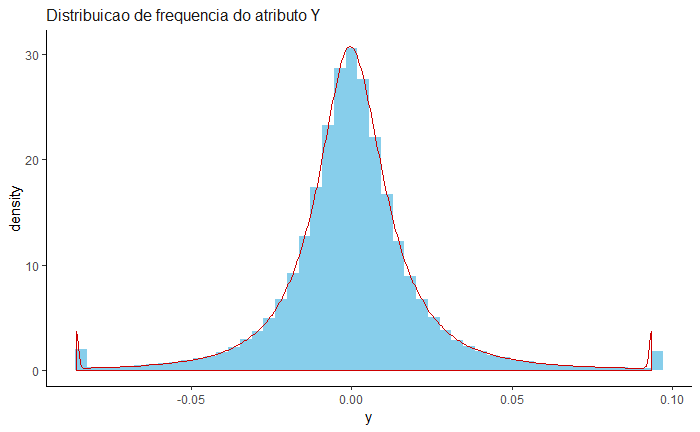

```r
# Criando um histograma e grafico de densidade do atributi y
ggplot(df, aes(x = y)) +
  geom_histogram(aes(y=..density..), bins = 50, fill = 'sky blue') +
  geom_density(color = 'red3') +
  theme_classic() +
  ggtitle("Distribuicao de frequencia do atributo Y") +
  theme(
    plot.title = element_text(color = "gray10", size = 12))
```

Conforme observado no histograma, existe uma grande quantidade de outliers tanto nos valores superiores como inferiores do atributo y.

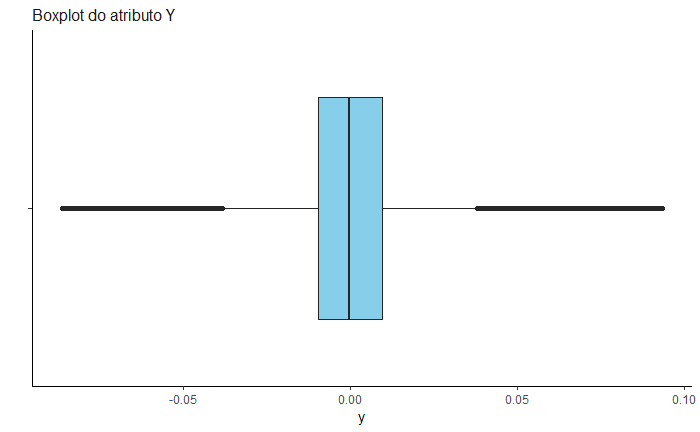

```r
# Criando um boxplot com base no atributo y
ggplot(df, aes(x = '', y = y)) +
  geom_boxplot(fill = 'sky blue', color = 'grey15') +
  theme_classic() +
  ggtitle("Boxplot do atributo Y") + xlab('') +
  coord_flip() +
  theme(
    plot.title = element_text(color = "gray10", size = 12))
```

Os valores extremos estao fora do intervalo do 1 e ultimo percentil, onde serao tratadas na fase de pre processamento.

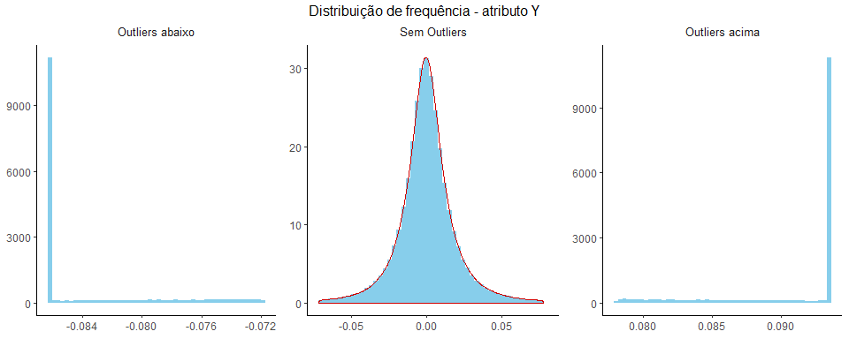

```r
# Criando um objeto com um histograma referente aos valores de y abaixo do percentil 5%
p1 <- df %>% select(y) %>% filter(y < quantile(y, 0.01)) %>%
  ggplot(aes(x = y)) +
  geom_histogram( bins = 50, fill = 'sky blue') +
  theme_classic() +
  ggtitle("Outliers abaixo") +
  theme(
    plot.title = element_text(color = "gray10", size = 10, hjust = 0.5),
    axis.title.y = element_blank(),
    axis.title.x = element_blank())

# Criando um objeto com um histograma referente aos valores de y acima do percentil 95%
p2 <- df %>% select(y) %>% filter(y > quantile(y, 0.99)) %>%
  ggplot(aes(x = y)) +
  geom_histogram(bins = 50, fill = 'sky blue') +
  theme_classic() +
  ggtitle("Outliers acima") +
  theme(
    plot.title = element_text(color = "gray10", size = 10, hjust = 0.5),
    axis.title.y = element_blank(),
    axis.title.x = element_blank())

# Criando um objeto com um histograma referente aos valores de y entre os percentis 5% e 95%
p3 <- df %>% select(y) %>% filter(between(y, quantile(y, 0.01), quantile(y, 0.99))) %>%
  ggplot(aes(x = y)) +
  geom_histogram(aes(y=..density..), bins = 50, fill = 'sky blue') +
  geom_density(color = 'red3') +
  theme_classic() +
  ggtitle("Sem Outliers") +
  theme(
    plot.title = element_text(color = "gray10", size = 10, hjust = 0.5),
    axis.title.y = element_blank(),
    axis.title.x = element_blank())

# Plotando os resultados
grid.arrange(p1, p3, p2, ncol=3, top = "Distribuição de frequência - atributo Y")
```

Distribuicao dos valores de timestamp onde apresenta uma pequena distribuicao para a direita.

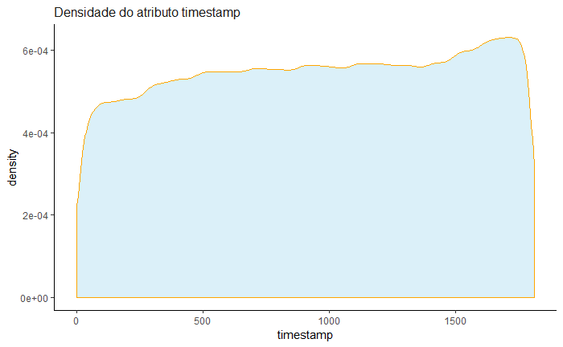

```r
# grafico de densidade da distribuicao de frequencia do atributo timestamp
ggplot(df, aes(x = timestamp)) +
  geom_density(alpha = 0.3,  fill = 'sky blue', color = 'orange') +
  theme_classic() +
  ggtitle("Densidade do atributo timestamp") +
  theme(
    plot.title = element_text(color = "gray10", size = 12))
```

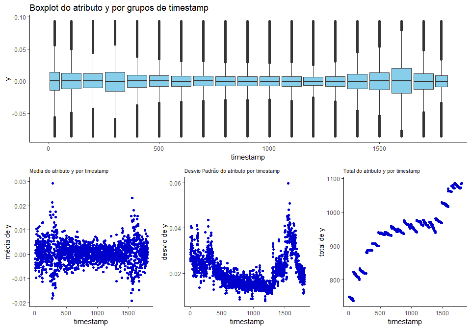

```r
# boxplot do atributi y x timestamp
p1 <- ggplot(df, aes(x = timestamp, y = y)) +
  geom_boxplot(aes(group = cut_width(timestamp, 100)), fill = 'sky blue') +
  theme_classic() +
  ggtitle("Boxplot do atributo y por grupos de timestamp")

# scatterplot de timestamp x media de y
p2 <- df %>% group_by(timestamp) %>%
  summarise(media = mean(y)) %>%
  ggplot(aes(y = media, x = timestamp)) +
  geom_point(color = 'blue3') +
  theme_classic() +
  theme(
    plot.title = element_text(color = "gray10", size = 8)) +
  ggtitle("Media do atributo y por timestamp") +
  xlab("timestamp") + ylab("média de y")

# scatterplot de timestamp x desvio padrao de y
p3 <- df %>% group_by(timestamp) %>%
  summarise(desvio = sd(y)) %>%
  ggplot(aes(y = desvio, x = timestamp)) +
  geom_point(color = 'blue3') +
  theme_classic() +
  theme(
    plot.title = element_text(color = "gray10", size = 8)) +
  ggtitle("Desvio Padrão do atributo por timestamp") +
  xlab("timestamp") + ylab("desvio de y")

# scatterplot de timestamp x contagem de y
p4 <- df %>% group_by(timestamp) %>%
  summarise(total = length(y)) %>%
  ggplot(aes(y = total, x = timestamp)) +
  geom_point(color = 'blue3') +
  theme_classic() +
  theme(
    plot.title = element_text(color = "gray10", size = 8)) +
  ggtitle("Total do atributo y por timestamp") +
  xlab("timestamp") + ylab("total de y")

# Plotando os resultados
grid.arrange(p1,p2,p3,p4, layout_matrix = rbind(c(1,1,1),c(2,3,4)))
```

Existe um grande volume de valores ausentes e outliers em varios atributos.

```r
# resumo estatistico dos dados
summary(df)
```

```
       id         timestamp        derived_0           derived_1           derived_2
 Min.   :   0   Min.   :   0.0   Min.   :-20174.97   Min.   :0.000e+00   Min.   :-9848.9
 1st Qu.: 550   1st Qu.: 504.0   1st Qu.:    -0.14   1st Qu.:0.000e+00   1st Qu.:   -0.1
 Median :1098   Median : 956.0   Median :     0.00   Median :0.000e+00   Median :    0.0
 Mean   :1094   Mean   : 945.6   Mean   :    -4.54   Mean   :7.729e+11   Mean   :   -0.3
 3rd Qu.:1657   3rd Qu.:1401.0   3rd Qu.:     0.12   3rd Qu.:0.000e+00   3rd Qu.:    0.2
 Max.   :2158   Max.   :1812.0   Max.   :  3252.53   Max.   :1.068e+16   Max.   : 3823.0
                                 NA's   :72959       NA's   :81029       NA's   :398651
   derived_3           derived_4       fundamental_0    fundamental_1        fundamental_2
 Min.   :-34341.76   Min.   :-8551.9   Min.   :-2.345   Min.   :-1.044e+13   Min.   :-1077.1
 1st Qu.:    -0.17   1st Qu.:   -0.1   1st Qu.:-0.200   1st Qu.: 0.000e+00   1st Qu.:   -0.2
 Median :     0.00   Median :    0.0   Median :-0.041   Median : 0.000e+00   Median :    0.0
 Mean   :    -0.50   Mean   :   18.0   Mean   :-0.020   Mean   :-5.704e+08   Mean   :   -0.2
 3rd Qu.:     0.30   3rd Qu.:    0.2   3rd Qu.: 0.130   3rd Qu.: 0.000e+00   3rd Qu.:    0.2
 Max.   :  1239.74   Max.   :67859.6   Max.   : 1.378   Max.   : 5.200e+02   Max.   :   76.8
 NA's   :149471      NA's   :406458    NA's   :23947    NA's   :679070       NA's   :368840
 fundamental_3    fundamental_5    fundamental_6    fundamental_7      fundamental_8    fundamental_9
 Min.   :-0.4     Min.   :  -0.1   Min.   : -1.1    Min.   :    -0.3   Min.   :-0.2     Min.   :-1685.8
 1st Qu.:-0.2     1st Qu.:  -0.1   1st Qu.: -0.1    1st Qu.:    -0.1   1st Qu.:-0.1     1st Qu.:   -0.1
 Median : 0.0     Median :   0.0   Median :  0.0    Median :     0.0   Median : 0.0     Median :    0.0
 Mean   : 0.0     Mean   :   0.8   Mean   :  0.1    Mean   :    48.7   Mean   : 0.1     Mean   :   -0.1
 3rd Qu.: 0.2     3rd Qu.:   0.4   3rd Qu.:  0.1    3rd Qu.:     0.2   3rd Qu.: 0.1     3rd Qu.:    0.2
 Max.   : 6.6     Max.   :1535.1   Max.   :121.5    Max.   :522165.3   Max.   :39.4     Max.   :   39.7
 NA's   :454380   NA's   :962020   NA's   :701625   NA's   :26340      NA's   :373166   NA's   :565567
 fundamental_10   fundamental_11   fundamental_12     fundamental_13   fundamental_14    fundamental_15
 Min.   : -0.08   Min.   :-750.5   Min.   :   -0.03   Min.   :  -0.3   Min.   :   -0.1   Min.   : -0.2
 1st Qu.: -0.04   1st Qu.:  -0.3   1st Qu.:   -0.02   1st Qu.:  -0.1   1st Qu.:    0.0   1st Qu.: -0.1
 Median :  0.01   Median :   0.0   Median :    0.00   Median :   0.0   Median :    0.0   Median :  0.0
 Mean   :  0.44   Mean   :  -0.3   Mean   :   61.72   Mean   :   0.1   Mean   :    3.1   Mean   :  0.2
 3rd Qu.:  0.17   3rd Qu.:   0.1   3rd Qu.:    0.11   3rd Qu.:   0.2   3rd Qu.:    0.2   3rd Qu.:  0.2
 Max.   :345.41   Max.   : 116.7   Max.   :92704.03   Max.   :1445.2   Max.   :40588.3   Max.   :254.3
 NA's   :112977   NA's   :368840   NA's   :110871     NA's   :355138   NA's   :356084    NA's   :354897
 fundamental_16   fundamental_17       fundamental_18      fundamental_19    fundamental_20
 Min.   :-980.2   Min.   :-3.637e+16   Min.   :-1695.405   Min.   :  -2.29   Min.   :-51902.38
 1st Qu.:  -0.2   1st Qu.: 0.000e+00   1st Qu.:   -0.211   1st Qu.:  -0.10   1st Qu.:    -0.10
 Median :   0.0   Median : 0.000e+00   Median :   -0.006   Median :   0.02   Median :    -0.01
 Mean   :  -0.2   Mean   : 7.088e+13   Mean   :   -0.823   Mean   :   0.40   Mean   :    -1.49
 3rd Qu.:   0.2   3rd Qu.: 0.000e+00   3rd Qu.:    0.170   3rd Qu.:   0.25   3rd Qu.:     0.24
 Max.   :   0.9   Max.   : 1.040e+18   Max.   :   48.894   Max.   :1152.07   Max.   :  1782.45
 NA's   :355138   NA's   :97222        NA's   :15833       NA's   :54588     NA's   :110871
```

[output cut: 105 more lines]

```
 Min.   :-1.6876   Min.   :-1.000   Min.   :-1.000   Min.   :-1.000   Min.   :-0.5251   Min.   :-0.44
 1st Qu.:-0.4050   1st Qu.: 0.000   1st Qu.: 0.000   1st Qu.: 0.000   1st Qu.:-0.1522   1st Qu.:-0.07
 Median :-0.0850   Median : 0.000   Median : 0.000   Median : 0.000   Median :-0.0148   Median : 0.00
 Mean   :-0.0858   Mean   :-0.091   Mean   :-0.082   Mean   :-0.073   Mean   : 0.0491   Mean   : 0.01
 3rd Qu.: 0.1910   3rd Qu.: 0.000   3rd Qu.: 0.000   3rd Qu.: 0.000   3rd Qu.: 0.1772   3rd Qu.: 0.08
 Max.   :49.5776   Max.   : 0.000   Max.   : 0.000   Max.   : 0.000   Max.   : 1.5693   Max.   : 0.68
 NA's   :2552      NA's   :19165    NA's   :19165    NA's   :20016    NA's   :2236      NA's   :44189
  technical_42     technical_43     technical_44          y
 Min.   :-1.000   Min.   :-2.000   Min.   :-0.13    Min.   :-0.0860941
 1st Qu.: 0.000   1st Qu.:-2.000   1st Qu.:-0.02    1st Qu.:-0.0095614
 Median : 0.000   Median :-0.660   Median : 0.00    Median :-0.0001571
 Mean   :-0.017   Mean   :-0.974   Mean   : 0.00    Mean   : 0.0002217
 3rd Qu.: 0.000   3rd Qu.: 0.000   3rd Qu.: 0.02    3rd Qu.: 0.0095210
 Max.   : 1.000   Max.   : 0.000   Max.   : 0.14    Max.   : 0.0934978
 NA's   :20001    NA's   :4686     NA's   :236779
```

### 4 - Pre processamento e limpeza dos dados

Removendo valores aunsentes, onde serao exluidos itens com mais de 20% de valores ausentes e itens com o percentual menor serao subistituidos pela media.

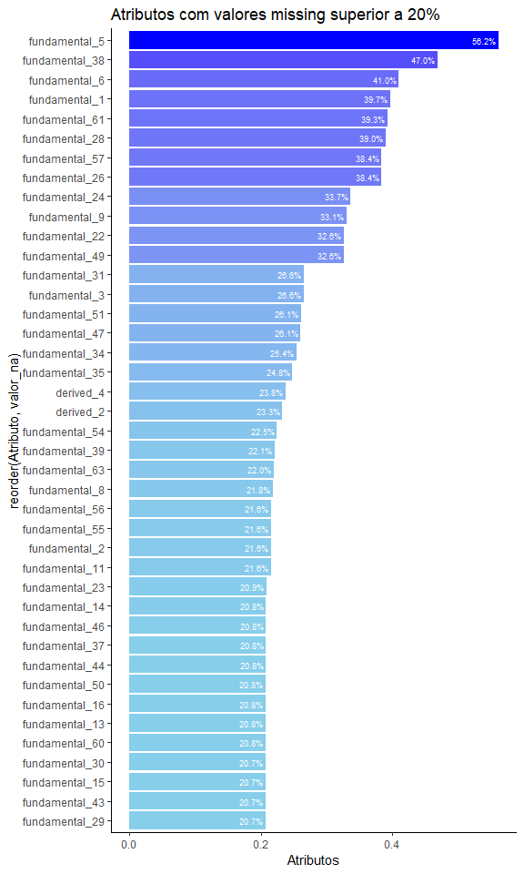

```r
# funcao para totalizar o valor relativo de dados ausentes
busca_valores_na <- function(x){
  sum(is.na(x)) / length(x)
}

# objeto com o total de valores NA por atributos
valores_na <- map_dfc(df, busca_valores_na)

# Plotando os atributos que contenham mais de 20% de valores ausentes
valores_na %>%  gather(key = "Atributo", value = "valor_na") %>%
  filter(valor_na > .2) %>%
  ggplot(aes(x = reorder(Atributo, valor_na), y = valor_na, fill = valor_na)) +
  geom_bar(stat = 'identity', show.legend = FALSE) +
  scale_fill_gradient(low='sky blue', high='blue') +
  geom_text(aes(label=scales::percent(valor_na)), hjust=1.1, size = 2.5, color = 'white') +
  coord_flip() +
  theme_classic() +
  ggtitle("Atributos com valores missing superior a 20%") +
  ylab("% Valores NA") + ylab("Atributos")
```

```r
# Itens com mais de 20% de valores missings + atributo id
remover <- c('derived_2', 'derived_4', 'fundamental_1', 'fundamental_2', 'fundamental_3', 'fundamental_5', 'fundamental_6', 'fundamental_8', 'fundamental_9', 'fundamental_11', 'fundamental_13', 'fundamental_14', 'fundamental_15', 'fundamental_16', 'fundamental_22', 'fundamental_23', 'fundamental_24', 'fundamental_26', 'fundamental_28', 'fundamental_29', 'fundamental_30', 'fundamental_31', 'fundamental_34', 'fundamental_35', 'fundamental_37', 'fundamental_38', 'fundamental_39', 'fundamental_43', 'fundamental_44', 'fundamental_46', 'fundamental_47', 'fundamental_49', 'fundamental_50', 'fundamental_51', 'fundamental_54', 'fundamental_55', 'fundamental_56', 'fundamental_57', 'fundamental_60', 'fundamental_61', 'fundamental_63', 'id')

# criando novo dataframe removendo atributos com mais de 20% de valores ausentes e substituindo demais valores pela media
df_clean <- df %>%
  select(-remover) %>%
  mutate_all(list(~ ifelse(is.na(.), mean(., na.rm = TRUE), .)))
```

Selecao de atributos com base no modelo rando forest

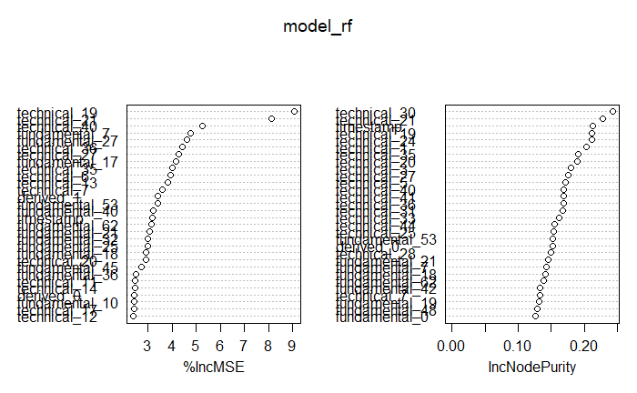

```r
# Dividindo os dados em treino e teste
train <-  sample_frac(df_clean, .01)

# Criando um modelo com randon forest para feature selection
model_rf <- randomForest(y ~ ., data = train, ntree = 10, importance=TRUE)

# removendo a base temporaria usada para cirar o modelo
rm(train)

# Plotando os atributos com maior importancia
varImpPlot(model_rf)
```

```r
# Atributos selecionados por MSE + y
features <- c("technical_35", "technical_19", "technical_21", "technical_40", "technical_27", "fundamental_53",
              "fundamental_42", "fundamental_59", "technical_3", "technical_24", "y")

# Atribuindo somente os atributos selecionados ao dataset_clean
df_clean %<>% select(features)
```

Com base no teste VIF nao existe multicoliniearidade com base nos atributos selecionados, pois os valores estao abaixo de 10.

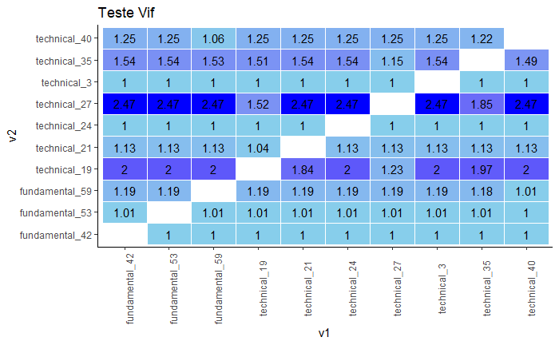

```r
# Função para calcular o teste vif
calcular_vif <- function(dados){

    dados = dados %>% select(-y)
    resultado = NULL

  for (item in colnames(dados)){

    # Modelo de regressao
    model = lm(paste(item, "~ ."), data = dados)

    # Criando um data frame com o resultado do teste vif
    resultado <- bind_rows(resultado,
                           vif(model) %>%
                            as.data.frame() %>%
                            rownames_to_column() %>%
                            rename("VIF" = 2, "v2" = rowname) %>%
                            mutate(v1 = item))
  }

  return(resultado)
}


# Realizando o teste vif
resultado <- calcular_vif(df_clean)

# Plotando os resultados
ggplot(resultado, aes(x = v1, y = v2, fill = VIF)) +
  geom_tile(show.legend = FALSE, color = 'white') +
  geom_text(aes(label=round(VIF,2))) +
  scale_fill_gradient(low='sky blue', high='blue') +
  theme_classic() +
  theme(axis.text.x = element_text(angle = 90)) +
  ggtitle("Teste Vif")
```

Conforme visto na exploracao dos dados, existem muitos outliers que podem influenciar no resultado do modelo.

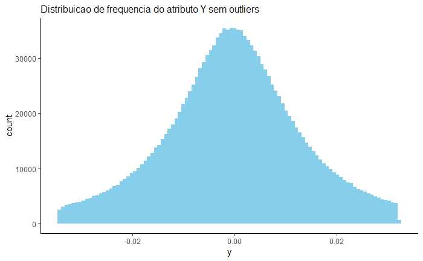

```r
# Funcao para remover os outliers com base no intervalo interquartil de 1.5
remove_out <- function(dados){

  # Primeiro e terceiro quartil
  first_q = as.numeric(quantile(dados$y, 0.25))
  third_q = as.numeric(quantile(dados$y, 0.70))

  # Distancia interquartil
  iqr = third_q - first_q

  # limites para outliers
  menor = first_q - 1.5 * iqr
  maior = third_q + 1.5 * iqr

  dados %<>% filter(between(y,menor, maior))

  return(dados)

}

# removendo outliers
df_clean <- remove_out(df_clean)

# Criando um histograma e grafico de densidade do atributi y
ggplot(df_clean, aes(x = y)) +
  geom_histogram(bins = 100, fill = 'sky blue') +
  theme_classic() +
  ggtitle("Distribuicao de frequencia do atributo Y sem outliers") +
  theme(
    plot.title = element_text(color = "gray10", size = 12))
```

A correlacao lineta com o atributo y en relação aos demais atributis é bem baixa, conforme podemos relatar pela imagem logo abaixo.

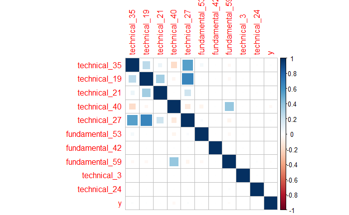

```r
# Plotando as correlacoes entre os atributos
df_clean %>% cor() %>%
  corrplot::corrplot(method = "square")
```

### 5 - Modelagem e Avaliação dos modelos

[output not shown]

[output cut: 990 more lines]

```r
# Carregando os dados para treinamento
train <- read_csv("dados//train.csv")
test <- read_csv("dados//test.csv")
```

```r
# Modelo xgb
model_xgb <- boost_tree(mode = "regression",
                        mtry = 8,
                        trees = 300,
                        min_n = 6,
                        learn_rate = 0.01) %>%
  set_engine("xgboost") %>%
  fit(y ~ ., data = train)
```

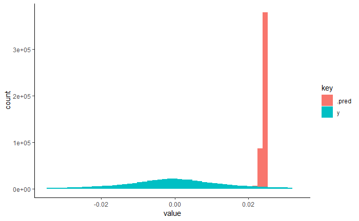